# Data Analysis Project

## The Behavioral Risk Factor Surveillance System (BRFSS) - 2013

### Background

The Behavioral Risk Factor Surveillance System (BRFSS) is a collaborative project between all of the states in the United States (US) and participating US territories and the Centers for Disease Control and Prevention (CDC). The BRFSS is administered and supported by CDC’s Population Health Surveillance Branch, under the Division of Population Health at the National Center for Chronic Disease Prevention and Health Promotion. BRFSS is an ongoing surveillance system designed to measure behavioral risk factors for the non-institutionalized adult population (18 years of age and older) residing in the US. The BRFSS was initiated in 1984, with 15 states collecting surveillance data on risk behaviors through monthly telephone interviews. Over time, the number of states participating in the survey increased; by 2001, 50 states, the District of Columbia, Puerto Rico, Guam, and the US Virgin Islands were participating in the BRFSS. Today, all 50 states, the District of Columbia, Puerto Rico, and Guam collect data annually and American Samoa, Federated States of Micronesia, and Palau collect survey data over a limited point- in-time (usually one to three months). In this document, the term “state” is used to refer to all areas participating in BRFSS, including the District of Columbia, Guam, and the Commonwealth of Puerto Rico.

The BRFSS objective is to collect uniform, state-specific data on preventive health practices and risk behaviors that are linked to chronic diseases, injuries, and preventable infectious diseases that affect the adult population. Factors assessed by the BRFSS in 2013 include tobacco use, HIV/AIDS knowledge and prevention, exercise, immunization, health status, healthy days — health-related quality of life, health care access, inadequate sleep, hypertension awareness, cholesterol awareness, chronic health conditions, alcohol consumption, fruits and vegetables consumption, arthritis burden, and seatbelt use. Since 2011, BRFSS conducts both landline telephone- and cellular telephone-based surveys. In conducting the BRFSS landline telephone survey, interviewers collect data from a randomly selected adult in a household. In conducting the cellular telephone version of the BRFSS questionnaire, interviewers collect data from an adult who participates by using a cellular telephone and resides in a private residence or college housing.

Health characteristics estimated from the BRFSS pertain to the non-institutionalized adult population, aged 18 years or older, who reside in the US. In 2013, additional question sets were included as optional modules to provide a measure for several childhood health and wellness indicators, including asthma prevalence for people aged 17 years or younger.

### Load packages

The following packages is upload to R and will be used for this data analysis project.

```r
library(ggplot2)
library(tidyverse)
library(dplyr)
library(statsr)
```

### Load data

The dataset `brfss2013` for this data analysis report is upload into R.

```r
load("brfss2013.RData")
```

## Part 1: Data

### Viewing the dataset characteristic:-

The following shows that the dataset contains **491775** rows and **330** column.

```r
dim(brfss2013)
```

```
## [1] 491775    330
```

The following shows the datasets **330** columns names.

```r
names(brfss2013)
```

```
##   [1] "X_state"   "fmonth"    "idate"     "imonth"    "iday"      "iyear"
##   [7] "dispcode"  "seqno"     "X_psu"     "ctelenum"  "pvtresd1"  "colghous"
##  [13] "stateres"  "cellfon3"  "ladult"    "numadult"  "nummen"    "numwomen"
##  [19] "genhlth"   "physhlth"  "menthlth"  "poorhlth"  "hlthpln1"  "persdoc2"
##  [25] "medcost"   "checkup1"  "sleptim1"  "bphigh4"   "bpmeds"    "bloodcho"
##  [31] "cholchk"   "toldhi2"   "cvdinfr4"  "cvdcrhd4"  "cvdstrk3"  "asthma3"
##  [37] "asthnow"   "chcscncr"  "chcocncr"  "chccopd1"  "havarth3"  "addepev2"
##  [43] "chckidny"  "diabete3"  "veteran3"  "marital"   "children"  "educa"
##  [49] "employ1"   "income2"   "weight2"   "height3"   "numhhol2"  "numphon2"
##  [55] "cpdemo1"   "cpdemo4"   "internet"  "renthom1"  "sex"       "pregnant"
##  [61] "qlactlm2"  "useequip"  "blind"     "decide"    "diffwalk"  "diffdres"
##  [67] "diffalon"  "smoke100"  "smokday2"  "stopsmk2"  "lastsmk2"  "usenow3"
##  [73] "alcday5"   "avedrnk2"  "drnk3ge5"  "maxdrnks"  "fruitju1"  "fruit1"
##  [79] "fvbeans"   "fvgreen"   "fvorang"   "vegetab1"  "exerany2"  "exract11"
##  [85] "exeroft1"  "exerhmm1"  "exract21"  "exeroft2"  "exerhmm2"  "strength"
```

[output cut: 40 more lines]

Based on the dataset, the following columns is selected for the purposed of the analysis for this projects:-

1. *X-state*
2. *genhlth*
3. *hlthpln1*
4. *income2*

The following shows the top 6 rows of the dataset based on the above selected columns.

```r
brfss2013 %>% group_by(X_state, genhlth, hlthpln1, income2) %>% summarise(n()) %>% head()
```

```
## # A tibble: 6 x 5
## # Groups:   X_state, genhlth, hlthpln1 [2]
##   X_state genhlth   hlthpln1 income2           `n()`
##   <fct>   <fct>     <fct>    <fct>             <int>
## 1 0       <NA>      <NA>     <NA>                  1
## 2 Alabama Excellent Yes      Less than $10,000    19
## 3 Alabama Excellent Yes      Less than $15,000    24
## 4 Alabama Excellent Yes      Less than $20,000    34
## 5 Alabama Excellent Yes      Less than $25,000    36
## 6 Alabama Excellent Yes      Less than $35,000    51
```

## Part 2: Research questions

### To identify the health care coverage across all states

In this section we will identify the coverage of each states and compares the coverage among other states. This will shows the differences of coverage among each states and identified which states have the higher coverage and which states have the lowest coverage.

### To identify the relationship between the income level and health care coverage

The income level is identified by the following levels:-

1. *Less than $10,000*
2. *Less than $15,000*
3. *Less than $20,000*
4. *Less than $25,000*
5. *Less than $35,000*
6. *Less than $50,000*
7. *Less than $75,000*
8. *$75,000 or more*

In this section we will identify if the level of income affected the health care coverage.

### To identify the relationship between income level and general health condition

The general health condition in the dataset is categorized as follows:-

1. *Excellent*
2. *Very good*
3. *Good*
4. *Fair*
5. *Poor*

In this section we will identify if the general health condition and level of income is affected each others.

## Part 3: Exploratory data analysis

### To identify the different of health care accessibility across all states

We know from previous analysis shows the dataset contains **491,775** rows, the datasets need to be cleaned and removed from unnecessary items such as **NA** values. The following shows the dataset column **X_state** after removed the **NA** values.

```r
sum(is.na(brfss2013$X_state))
```

```
## [1] 0
```

The above shows that **X-state** column does not have any **NA** values.

The following shows the **NA** values for dataset column **hlthpln1**.

```r
sum(is.na(brfss2013$hlthpln1))
```

```
## [1] 1904
```

Prior to proceed further in the analysis, we need to identify the accuracy of the analysis after removing the **NA** value.

```r
(sum(is.na(brfss2013$hlthpln1)) / length(brfss2013$hlthpln1)) * 100
```

```
## [1] 0.3871689
```

The following shows the dataset after removing the **NA** values. Additional column that’s shows the non health coverage, total health coverage and the ratio of the health coverage is included in the dataset prior plotting the graph.

```r
states <- brfss2013 %>%
    select(X_state, hlthpln1) %>%
    na.omit() %>%
    group_by(X_state) %>%
    summarise(hlth = sum(hlthpln1 == "Yes", na.rm = T), nohlth = sum(hlthpln1 == "No", na.rm = T)) %>%
        mutate(total = hlth + nohlth) %>%
    mutate(ratio = hlth / (hlth + nohlth)) %>%
    arrange(desc(ratio))
head(states)
```

```
## # A tibble: 6 x 5
##   X_state               hlth nohlth total ratio
##   <fct>                <int>  <int> <int> <dbl>
## 1 Massachusetts        14377    642 15019 0.957
## 2 District of Columbia  4698    220  4918 0.955
## 3 Puerto Rico           5708    286  5994 0.952
## 4 Iowa                  7606    527  8133 0.935
## 5 Vermont               5949    427  6376 0.933
## 6 Maryland             12064    904 12968 0.930
```

```r
nrow(states)
```

```
## [1] 53
```

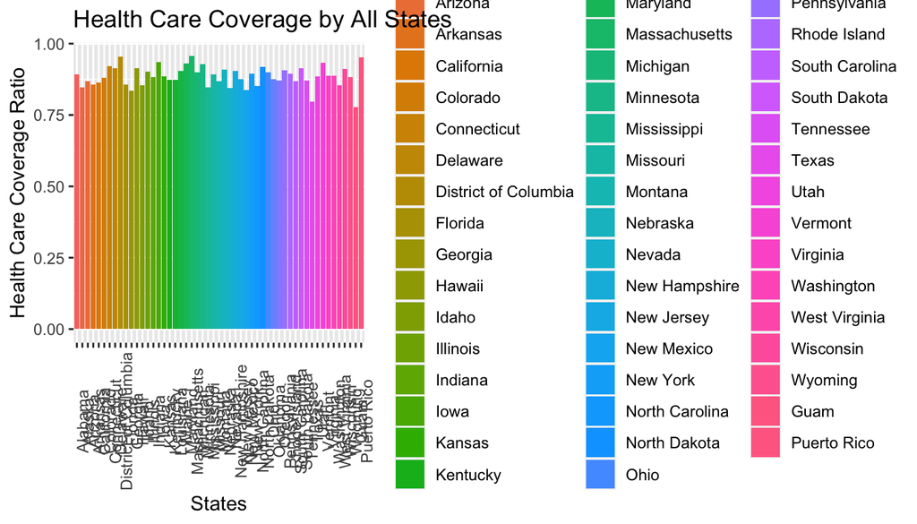

```r
ggplot(states, aes(X_state, ratio, fill = X_state)) + geom_bar(stat = "identity") +
    xlab("States") +
    ylab("Health Care Coverage Ratio") + theme(axis.text.x = element_text(angle = 90)) +
    ggtitle("Health Care Coverage by All States")
```

Based on the above graph shows that most of the states have coverage more than **0.75**. Therefore, we set a health coverage threshold at **0.8**, in order to identify which states have a lower health coverage.

```r
below <- states %>%
    filter(ratio < 0.8)
nrow(below)
```

```
## [1] 2
```

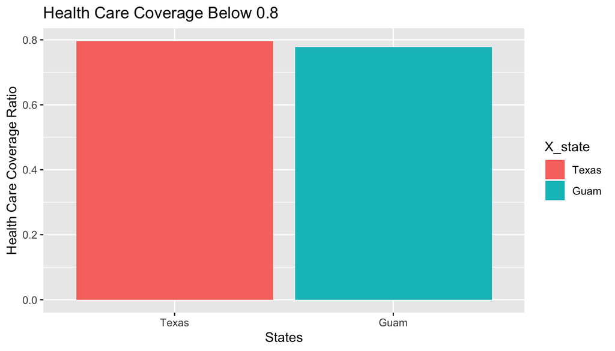

```r
ggplot(below, aes(X_state, ratio, fill = X_state)) + geom_bar(stat = "identity") +
    xlab("States") +
    ylab("Health Care Coverage Ratio") +
    ggtitle("Health Care Coverage Below 0.8")
```

Based on the above graph shows that from **53 states**, **2 states** with health coverage below **0.8**, which are **Texas** and **Guam**.

```r
above <- states %>%
    filter(ratio > 0.9)
nrow(above)
```

```
## [1] 20
```

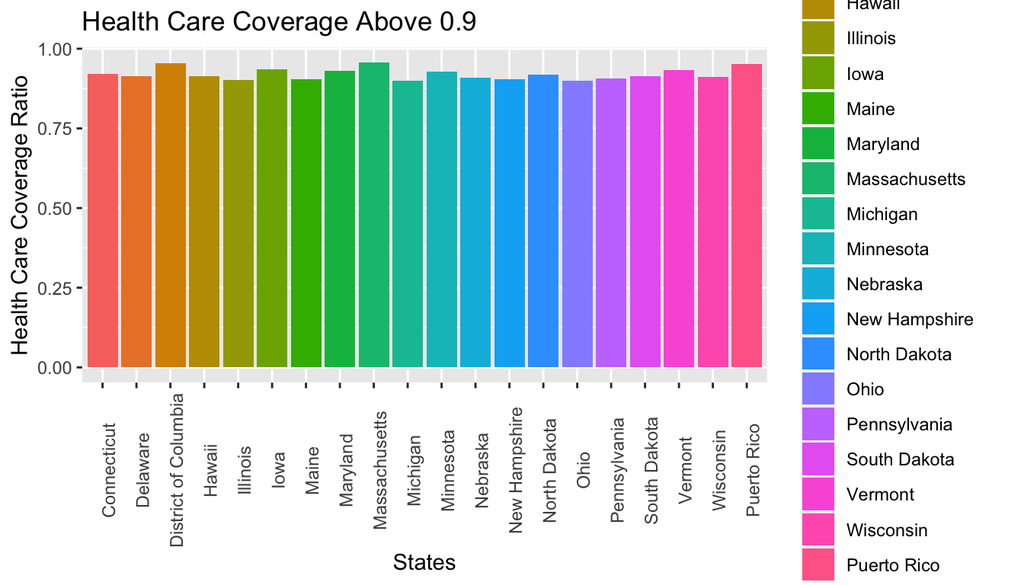

```r
ggplot(above, aes(X_state, ratio, fill = X_state)) +
        geom_bar(stat = "identity") + xlab("States") +
        ylab("Health Care Coverage Ratio") +
        theme(axis.text.x = element_text(angle = 90)) +
        ggtitle("Health Care Coverage Above 0.9")
```

Based on the above graph shows that there are **20 states** out from 53 states that have health coverage more than **0.9**. This also shows that there are **31 states** that have health coverage between **0.8 and 0.9**.

### To identify the relationship between the income level and health care accessibility

Before proceed with the analysis, we need to identify if there is **NA** value in the dataset column **income2**. The following shows the nos. of rows for **NA** values.

```r
brfss2013 %>% group_by(income2) %>% summarise(count=n())
```

```
## # A tibble: 9 x 2
##   income2            count
##   <fct>              <int>
## 1 Less than $10,000  25441
## 2 Less than $15,000  26794
## 3 Less than $20,000  34873
## 4 Less than $25,000  41732
## 5 Less than $35,000  48867
## 6 Less than $50,000  61509
## 7 Less than $75,000  65231
## 8 $75,000 or more   115902
## 9 <NA>               71426
```

```r
(sum(is.na(brfss2013$income2))/ length(brfss2013$income2)) * 100
```

```
## [1] 14.52412
```

Based on the total dataset value shows that the **NA** value consists of **14.5%** from overall dataset values. Therefore removing the NA values from the dataset will give **85.5%** accuracy of the analysis.

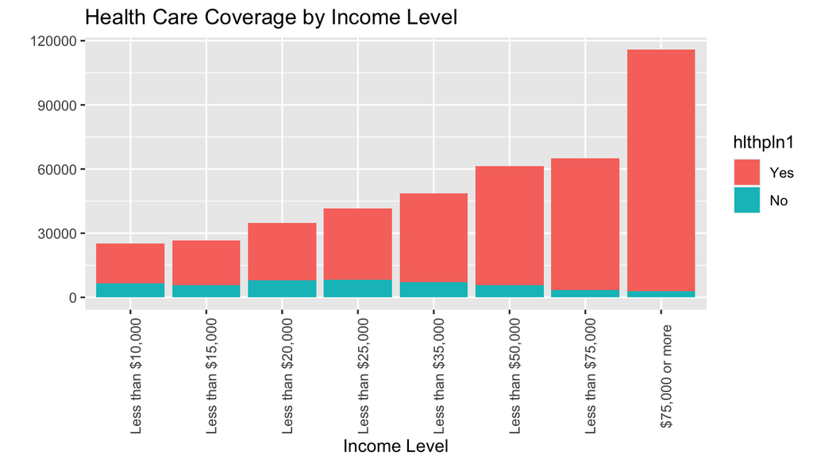

```r
income_hlth <- brfss2013 %>%
  select(income2, hlthpln1) %>%
  na.omit()

ggplot(income_hlth, aes(income2, fill = hlthpln1)) + geom_bar() +
     xlab("Income Level") +
    ylab("") + theme(axis.text.x = element_text(angle = 90)) +
    ggtitle("Health Care Coverage by Income Level")
```

Based on the above graph shows that higher income level have more health care coverage.

### To identify the relationship between income level and general health condition

The following show the dataset column genhlth which shows that there are **1985** with a **NA** values. Based on the overall dataset, the NA values only consists of **0.4%**. This will give the accuracy of the analysis of **99.6%**.

```r
brfss2013 %>% group_by(genhlth) %>% summarise(count=n())
```

```
## # A tibble: 6 x 2
##   genhlth    count
##   <fct>      <int>
## 1 Excellent  85482
## 2 Very good 159076
## 3 Good      150555
## 4 Fair       66726
## 5 Poor       27951
## 6 <NA>        1985
```

```r
(sum(is.na(brfss2013$genhlth))/ length(brfss2013$genhlth)) * 100
```

```
## [1] 0.4036399
```

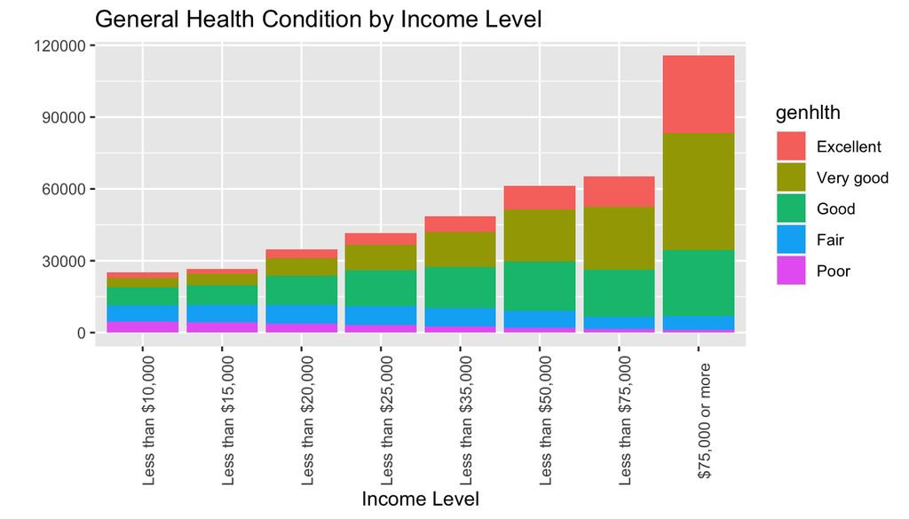

```r
genplot <- brfss2013 %>%
  select(income2, genhlth) %>%
  na.omit()

ggplot(genplot, aes(income2, fill = genhlth)) + geom_bar() + xlab("Income Level") + ylab("") +
theme(axis.text.x = element_text(angle = 90)) +
ggtitle("General Health Condition by Income Level")
```

Based on the above graph shows that higher income level have more excellent and very good level of general health condition. While for lower income level tend to have less excellent and very good level of general health condition.

## Summary

### To identify the relationship between the income level and health care coverage

1. The dataset consist of **NA** value of **14.5%** from overall dataset values. Therefore, the estimated accuracy of the analysis is **85.5%**
2. The analysis shows that higher income level have more health care coverage

### To identify the relationship between income level and general health condition

1. The dataset consist of **NA** values of **0.4%** from overall dataset values. Therefore, the estimated accuracy of the analysis is **99.6%**
2. The analysis shows that higher income level have more excellent and very good level of general health condition
3. While for lower income level tend to have less excellent and very good level of general health condition